# HW4

Liming Ning

Hansen Wang

William Walsh

Kevin Sun

2022/3/18

# 1 Q1

```r
hd.data = fread("Framingham.dat")
setnames(hd.data,1,"HD")
hd.data[,":="(HD = as.factor(HD),SEX = as.factor(SEX))]
view(dfSummary(hd.data),method = "render") # some missings here
```

Data Frame Summary

hd.data

**Dimensions**: 1407 x 8  
**Duplicates**: 0

| **No** | **Variable** | **Stats / Values** | **Freqs (% of Valid)** | **Graph** | **Valid** | **Missing** |
| --- | --- | --- | --- | --- | --- | --- |
| 1 | HD [factor] | 1. 0 2. 1 | 1095 ( 77.9% ) 311 ( 22.1% ) |  | 1406 (99.9%) | 1 (0.1%) |
| 2 | AGE [integer] | Mean (sd) : 52.4 (4.8) min ≤ med ≤ max: 45 ≤ 52 ≤ 62 IQR (CV) : 8 (0.1) | 18 distinct values |  | 1407 (100.0%) | 0 (0.0%) |
| 3 | SEX [factor] | 1. FEMALE 2. MALE | 738 ( 52.5% ) 669 ( 47.5% ) |  | 1407 (100.0%) | 0 (0.0%) |
| 4 | SBP [integer] | Mean (sd) : 148.1 (28) min ≤ med ≤ max: 90 ≤ 142 ≤ 300 IQR (CV) : 30 (0.2) | 94 distinct values |  | 1407 (100.0%) | 0 (0.0%) |
| 5 | DBP [integer] | Mean (sd) : 90.1 (14.2) min ≤ med ≤ max: 50 ≤ 90 ≤ 160 IQR (CV) : 18 (0.2) | 60 distinct values |  | 1407 (100.0%) | 0 (0.0%) |
| 6 | CHOL [integer] | Mean (sd) : 234.7 (46.3) min ≤ med ≤ max: 96 ≤ 230 ≤ 430 IQR (CV) : 64 (0.2) | 179 distinct values |  | 1407 (100.0%) | 0 (0.0%) |
| 7 | FRW [integer] | Mean (sd) : 105.4 (17.8) min ≤ med ≤ max: 52 ≤ 103 ≤ 222 IQR (CV) : 20 (0.2) | 100 distinct values |  | 1396 (99.2%) | 11 (0.8%) |
| 8 | CIG [integer] | Mean (sd) : 8 (11.6) min ≤ med ≤ max: 0 ≤ 0 ≤ 60 IQR (CV) : 20 (1.4) | 13 distinct values |  | 1405 (99.9%) | 2 (0.1%) |

Generated by summarytools 1.0.0 ([R](https://www.r-project.org/) version 4.0.3)  
2022-03-20

```r
hd.data.clean = na.omit(hd.data)
```

## 1.1 Identifying risk factors

### 1.1.1 Understand the likelihood func

**5 samples**

```r
set.seed(50)
sample.hd = hd.data.clean[sample(nrow(hd.data.clean),5),.(HD,SBP)]
kbl(sample.hd,caption = '5 samples of hd data set', booktabs = T,linesep = "")%>%
  kable_styling(latex_options = c("HOLD_position"))
```

5 samples of hd data set

| HD | SBP |
| --- | --- |
| 1 | 152 |
| 0 | 110 |
| 0 | 154 |
| 1 | 160 |
| 0 | 182 |

**Likelihood function**

Generally,

$$L(\beta,Data) = \Pi_{i=1}^5 \theta_i^{y_i} (1-\theta_i)^{1-y_i}=\Pi_{i=1}^5 (\frac{e^{x_i'\beta}}{1+e^{x_i'\beta}})^{y_i} (\frac{1}{1+e^{x_i'\beta}})^{1-y_i},$$
where $x_i$ is the value of covariates for i (including 1) and $\beta$ is the vector of the parameters. When there is only SBP, $x_i$ just includes 1 and SBP.

**Find mle**

```r
sample.glm = glm(HD~.,data = sample.hd,family = "binomial")
stargazer(sample.glm,header=FALSE, type=output_format,no.space = T)
```

|  | *Dependent variable:* |
| --- | --- |
|  | HD |
| SBP | 0.014 |
|  | (0.041) |
| Constant | -2.546 |
|  | (6.407) |
| Observations | 5 |
| Log Likelihood | -3.304 |
| Akaike Inf. Crit. | 10.610 |
| *Note:* | p<0.1; p<0.05; p<0.01 |

The logit function:
$$logit = -2.5456 + 0.014 \times SBP.$$

$$P(HD=1|HBP) = \frac{e^{logit}}{1+e^{logit}}.$$

The MLE is obtained by simply maximizing the likelihood function shown in (ii). As with the actual method employed, refer to IRLS method.

**Evaluate the prob**

```r
sample.pre = predict(sample.glm,hd.data[nrow(hd.data)],type = "response")
```

The predicted probability with only 5 samples: 0.242.

### 1.1.2 Identify important risk factors for `Heart.Disease`.

```r
fit1 = glm(HD~SBP,data = hd.data.clean,family = "binomial")
```

**Which var to add first? By z-value**

```r
fit1.sum.list = list()
new.z = c()
j = 1
for (i in c(2,3,5,6,7,8)) {
  data.sub = hd.data.clean[,c(1,4,i),with=F]
  fit1.new = glm(HD~.,data = data.sub,family = "binomial")
  fit1.sum.list[[j]] = summary(fit1.new)
  new.z[j] = fit1.sum.list[[j]]$coefficients[3,3] # z-value of the new var
  j = j + 1
}
best.fit = which.max(new.z) # should include sex by z

fit2 = glm(HD~.,data = hd.data.clean[,c(1,3,4),with=F],family = "binomial")
```

We should include `SEX` as it has the largest z value.

**Comparison of the residual deviance**

Yes the residual deviance of fit2 is always smaller than that of fit1. Consider the maximization problem of two variables. If we let $\beta_2 = 0$, the problem is equivalent to the maximization in one variable. Thus, the optimization result in fit1 is actually suboptimal in fit2. Given that the deviance is proportional to negative log likelihood, the deviance in fit2 must be smaller.

**Tests**

```r
waldtest(fit1,fit2) # note: use F-statistics here
```

```
## Wald test
##
## Model 1: HD ~ SBP
## Model 2: HD ~ SEX + SBP
##   Res.Df Df    F  Pr(>F)
## 1   1391
## 2   1390  1 41.8 1.4e-10 ***
## ---
## Signif. codes:  0 '***' 0.001 '**' 0.01 '*' 0.05 '.' 0.1 ' ' 1
```

```r
lrtest(fit1,fit2) # same as Anova() in 'car' package
```

```
## Likelihood ratio test
##
## Model 1: HD ~ SBP
## Model 2: HD ~ SEX + SBP
##   #Df LogLik Df Chisq Pr(>Chisq)
## 1   2   -709
## 2   3   -687  1  43.7    3.8e-11 ***
## ---
## Signif. codes:  0 '***' 0.001 '**' 0.01 '*' 0.05 '.' 0.1 ' ' 1
```

The added variable is both significant in two tests. The p-value in Wald test (F-statistics): $1.4 \times 10^{-10}$. In LR test: $3.8 \times 10^{-11}.$ They are not the same since they use different statistics.

### 1.1.3 Model building

**Backward selection**

For a better manifestation, we hide the regression results here.

```r
j = 0
data = hd.data.clean
while (j<1) {
  reg = glm(HD~.,data = data,family = "binomial")
  sum.reg = summary(reg)
  max.p.num = which.max(sum.reg$coefficients[-1,4])
  max.p.name = names(max.p.num)
  max.p.info = sum.reg$coefficients[max.p.num+1,]
  if(max.p.info[4] > 0.05){
    data = data[,-max.p.name,with=F]
    print(paste0("Eliminate var: ",max.p.name," p-value: ",round(max.p.info[4],digits = 3)))
  }else{
    break
  }
}
```

We present our final model by backward selection next.

```r
fit.backward = reg
stargazer(fit.backward,header=FALSE, type=output_format,no.space = T)
```

|  | *Dependent variable:* |
| --- | --- |
|  | HD |
| AGE | 0.057*** |
|  | (0.014) |
| SEXMALE | 0.990*** |
|  | (0.145) |
| SBP | 0.017*** |
|  | (0.002) |
| CHOL | 0.004*** |
|  | (0.001) |
| Constant | -8.409*** |
|  | (0.909) |
| Observations | 1,393 |
| Log Likelihood | -674.500 |
| Akaike Inf. Crit. | 1,359.000 |
| *Note:* | p<0.1; p<0.05; p<0.01 |

**Exhaustive search with AIC**

The best model found by bestglm() is presented below:

```r
xy = data.table(hd.data.clean[,-1],hd.data.clean[,1])
fit.exhaustive = bestglm(xy,family = binomial,method = "exhaustive",IC = "AIC",nvmax = 10)
fit.exhau.best = fit.exhaustive$BestModel
stargazer(fit.exhau.best,header=FALSE, type=output_format,no.space = T)
```

|  | *Dependent variable:* |
| --- | --- |
|  | y |
| AGE | 0.062*** |
|  | (0.015) |
| SEXMALE | 0.911*** |
|  | (0.157) |
| SBP | 0.016*** |
|  | (0.002) |
| CHOL | 0.004*** |
|  | (0.002) |
| FRW | 0.006 |
|  | (0.004) |
| CIG | 0.012** |
|  | (0.006) |
| Constant | -9.228*** |
|  | (0.996) |
| Observations | 1,393 |
| Log Likelihood | -671.600 |
| Akaike Inf. Crit. | 1,357.000 |
| *Note:* | p<0.1; p<0.05; p<0.01 |

There is no guarantee that all the remaining p-values are smaller than 0.05. This final model is not the same as the model from backwards elimination, as all p-values in the previous one are smaller than 0.05.

**Summary according to the exhaustive model**

In the model found in (ii), six variables are included. They are important in the sense that the decrease they brought to the deviance is larger than the penalty for them (which is 2 in the case of AIC).

Age, Sexmale, SBP, CHOL, FRW, CIG are all positively correlated to the probability of heart diseases.

**Prediction**

```r
liz.prob = predict(fit.exhau.best,hd.data[nrow(hd.data)],type = "response")
```

The probability for Liz having heart diseases: 0.0346.

## 1.2 Classification

### 1.2.1 ROC/FDR

**ROC curve with fit1**

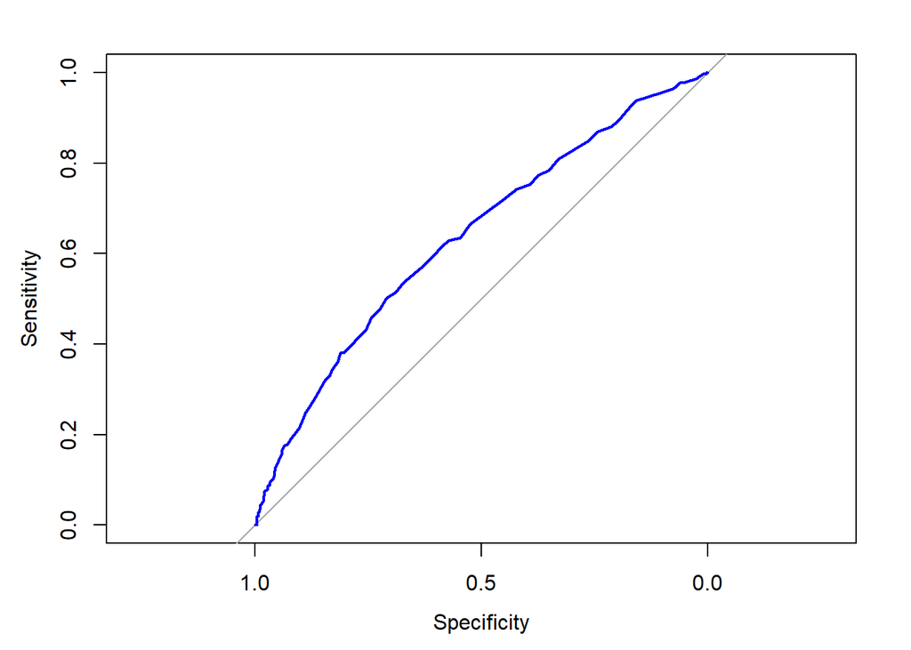

```r
roc.fit1 = roc(hd.data.clean$HD,fit1$fitted.values,plot=T,col="blue")
```

The ROC curve using fit1 is illustrated above. It reports the trade-off between specificity and sensitivity, i.e., the true negative rate and the true positive rate. We can find the best possible combinations of the two rates in this graph and decide which to choose.

```r
num = max(roc.fit1$sensitivities[roc.fit1$specificities>0.9])
threshold = roc.fit1$thresholds[roc.fit1$sensitivities == num]
```

The threshold satisfying the condition: 0.2982.

**Two ROC curves**

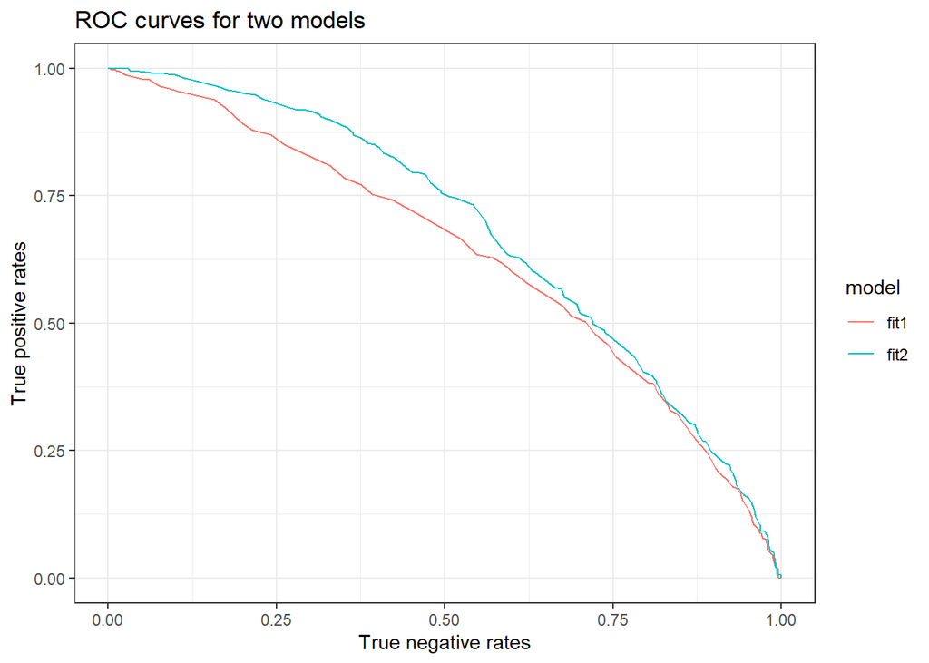

```r
roc.fit2 = roc(hd.data.clean$HD,fit2$fitted.values)
roc.data.fit1 = data.table(spec = roc.fit1$specificities,sens = roc.fit1$sensitivities,model = "fit1")
roc.data.fit2 = data.table(spec = roc.fit2$specificities,sens = roc.fit2$sensitivities,model = "fit2")
roc.data.combine = rbind(roc.data.fit1,roc.data.fit2)
ggplot(roc.data.combine,aes(x=spec,y=sens,group=model,color=model))+
  geom_line()+
  xlab("True negative rates")+
  ylab("True positive rates")+
  labs(title = "ROC curves for two models")+
  theme_bw()
```

In most of the time, the ROC curve for fit2 is higher than the ROC curve for fit1. Since fit2 always has a better in-sample predictive power than fit1, it’s possible that it can achieve a higher sensitivity/specificity than fit1 when a minimum of the other statistics is stipulated. However, we can see that when the true negative rate is close to 1, fit2 actually falls below fit1. It is also reasonable because the in-sample predictive power is just higher than fit1 in aggregation instead of everywhere.

**Estimation with threshold 0.5**

The confusion matrix for fit1:

```r
fit1.pred = ifelse(fit1$fitted.values>0.5,1,0)
fit2.pred = ifelse(fit2$fitted.values>0.5,1,0)
confusionMatrix(as.factor(fit1.pred),reference = hd.data.clean$HD,positive = "1")
```

```
## Confusion Matrix and Statistics
##
##           Reference
## Prediction    0    1
##          0 1075  298
##          1   11    9
##
##                Accuracy : 0.778
##                  95% CI : (0.755, 0.8)
##     No Information Rate : 0.78
##     P-Value [Acc > NIR] : 0.566
##
##                   Kappa : 0.029
##
##  Mcnemar's Test P-Value : <2e-16
##
##             Sensitivity : 0.02932
##             Specificity : 0.98987
##          Pos Pred Value : 0.45000
##          Neg Pred Value : 0.78296
##              Prevalence : 0.22039
##          Detection Rate : 0.00646
##    Detection Prevalence : 0.01436
##       Balanced Accuracy : 0.50959
##
##        'Positive' Class : 1
##
```

The confusion matrix for fit2:

```r
confusionMatrix(as.factor(fit2.pred),reference = hd.data.clean$HD,positive = "1")
```

```
## Confusion Matrix and Statistics
##
##           Reference
## Prediction    0    1
##          0 1067  290
##          1   19   17
##
##                Accuracy : 0.778
##                  95% CI : (0.755, 0.8)
##     No Information Rate : 0.78
##     P-Value [Acc > NIR] : 0.566
##
##                   Kappa : 0.055
##
##  Mcnemar's Test P-Value : <2e-16
##
##             Sensitivity : 0.0554
##             Specificity : 0.9825
##          Pos Pred Value : 0.4722
##          Neg Pred Value : 0.7863
##              Prevalence : 0.2204
##          Detection Rate : 0.0122
##    Detection Prevalence : 0.0258
##       Balanced Accuracy : 0.5189
##
##        'Positive' Class : 1
##
```

We can see that the positive prediction value in fit2 is 0.4722 while that in fit1 is 0.4500. Thus we prefer fit2.

**PPV and NPV**

```r
data.fit1 = data.table(thres = roc.fit1$thresholds,spec = roc.fit1$specificities,sens = roc.fit1$sensitivities,pos.num = length(which(hd.data.clean$HD == "1")),neg.num = nrow(hd.data.clean)-length(which(hd.data.clean$HD == "1")),model = "fit1")
data.fit1[,":="(ppv = pos.num * sens/(pos.num*sens + neg.num*(1-spec)),
                npv = neg.num * spec/(neg.num * spec + pos.num * (1-sens)))]
fit1.use = data.fit1 %>%
  pivot_longer(c(ppv,npv),names_to = "type")

fit1.pv = ggplot(fit1.use,aes(x=thres,y=value,group=type,color=type))+
  geom_line()+
  xlab("Thresholds for p")+
  ylab("PPV or NPV")+
  scale_x_continuous(limits = c(0,1),breaks = seq(0,1,0.1))+
  scale_y_continuous(limits = c(0,1),breaks = seq(0,1,0.1))+
  labs(title = "PPV and NPV with different thresholds, fit1")+
  theme_bw()
```

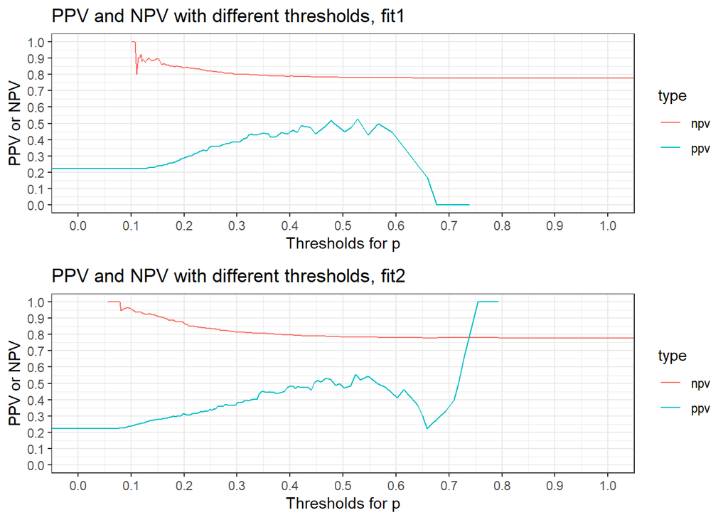

```r
data.fit2 = data.table(thres = roc.fit2$thresholds,spec = roc.fit2$specificities,sens = roc.fit2$sensitivities,pos.num = length(which(hd.data.clean$HD == "1")),neg.num = nrow(hd.data.clean)-length(which(hd.data.clean$HD == "1")),model = "fit2")
data.fit2[,":="(ppv = pos.num * sens/(pos.num*sens + neg.num*(1-spec)),
                npv = neg.num * spec/(neg.num * spec + pos.num * (1-sens)))]
fit2.use = data.fit2 %>%
  pivot_longer(c(ppv,npv),names_to = "type")

fit2.pv = ggplot(fit2.use,aes(x=thres,y=value,group=type,color=type))+
  geom_line()+
  xlab("Thresholds for p")+
  ylab("PPV or NPV")+
  scale_x_continuous(limits = c(0,1),breaks = seq(0,1,0.1))+
  scale_y_continuous(limits = c(0,1),breaks = seq(0,1,0.1))+
  labs(title = "PPV and NPV with different thresholds, fit2")+
  theme_bw()

plot_grid(fit1.pv,fit2.pv,nrow = 2)
```

Generally fit2 still performs better in terms of PPV and NPV. They are both generally higher than that for fit1.

### 1.2.2 Bayes classification

**Linear boundary**

We classify i into $\hat{Y}=1$ if $\frac{P(Y_i=1|X_i)}{P(Y_i=0|X_i)}>\frac{a_{0,1}}{a_{1,0}}.$

In our final model, the boundary:
$$\beta' X = -ln(10), where$$

$\beta = [-9.2279, 0.0615, 0.9113, 0.016, 0.0045, 0.006, 0.0123]'$, X is the included covariates (Age, Sexmale, SBP, CHOL, FRW, CIG) in addition to a constant 1.

**Estimated misclassification error**

```r
ratio1 = 1/10
thres1 = ratio1/(1+ratio1)
class1 = ifelse(fit.exhau.best$fitted.values>thres1,1,0)
confu1 = confusionMatrix(as.factor(class1),reference = hd.data.clean$HD,positive = "1")
mce1 = (confu1$table[1,2]*10+confu1$table[2,1])/nrow(hd.data.clean)
```

The estimated misclassification error here: 0.7143.

**Classify Liz**

```r
Liz.class = liz.prob > thres1
```

Liz’s class: 0.

**Performance of Bayesian classifier, ratio=10**

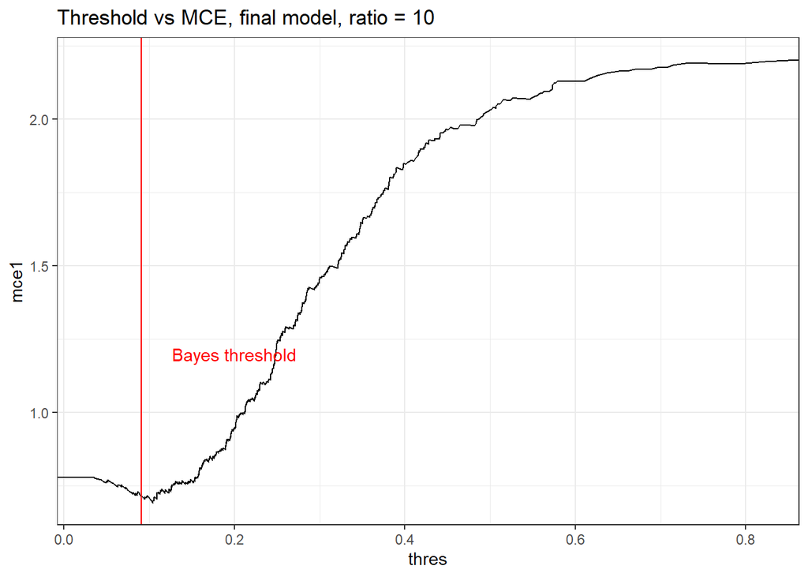

```r
roc.fit.final = roc(hd.data.clean$HD,fit.exhau.best$fitted.values)

data.fit.final = data.table(thres = roc.fit.final$thresholds,spec = roc.fit.final$specificities,sens = roc.fit.final$sensitivities,pos.num = length(which(hd.data.clean$HD == "1")),neg.num = nrow(hd.data.clean)-length(which(hd.data.clean$HD == "1")),model = "fit.final")
data.fit.final[,":="(a10 = pos.num*(1-sens),a01 = neg.num*(1-spec))]
data.fit.final[,":="(mce1 = (10*a10+a01)/nrow(hd.data.clean),
                     mce2 = (a10+a01)/nrow(hd.data.clean))]

ggplot(data.fit.final,aes(x=thres,y=mce1))+
  geom_line()+
  geom_vline(color="red",xintercept = thres1)+
  labs(title = "Threshold vs MCE, final model, ratio = 10")+
  annotate("text",x=0.2,y=1.2,color="red",label="Bayes threshold")+
  theme_bw()
```

**Performance of Bayesian classifier, ratio=1**

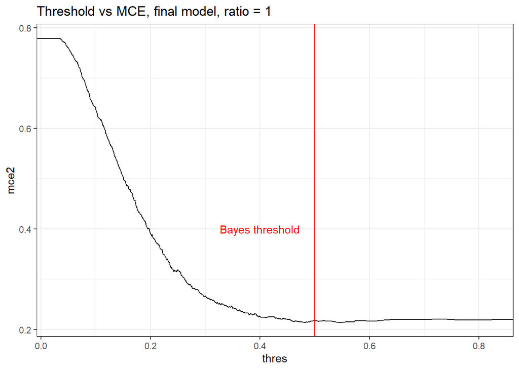

```r
ratio2 = 1
thres2 = ratio2/(1+ratio2)
class2 = ifelse(fit.exhau.best$fitted.values>thres2,1,0)
confu2 = confusionMatrix(as.factor(class2),reference = hd.data.clean$HD,positive = "1")
mce2 = (confu2$table[1,2]+confu1$table[2,1])/nrow(hd.data.clean)

ggplot(data.fit.final,aes(x=thres,y=mce2))+
  geom_line()+
  geom_vline(color="red",xintercept = thres2)+
  labs(title = "Threshold vs MCE, final model, ratio = 1")+
  annotate("text",x=0.4,y=0.4,color="red",label="Bayes threshold")+
  theme_bw()
```

From the graphs shown above we can see that Bayes rule does give us good thresholds in terms of minimizing weighted misclassification error.